# Feller-Style Combinatorial Probability in Finite Sample Spaces

Author

Sudipto Banerjee  
Department of Biostatistics  
Department of Statistics & Data Science  
Institute of the Environment & Sustainability  
UCLA

# 1 Introduction: William Feller’s Classical Combinatorial Framework

In Lecture 1, we established the axiomatic probability space $(\Omega, \mathcal{F}, P)$ for finite sample spaces and defined sampling designs as probability measures on collections of subsets. We now turn to William Feller’s classic approach to probability (from *An Introduction to Probability Theory and Its Applications*, Vol. 1): evaluating probabilities in finite sample spaces where elementary outcomes are **equally likely**.

Under equal likelihood, if $\Omega = \{\omega_1, \dots, \omega_M\}$ and $p(\{\omega_m\}) = 1/M$ for all $m$, the probability of an event $A \subseteq \Omega$ reduces purely to counting:

$$P(A) = \frac{\vert{}A\vert{}}{\vert{}\Omega\vert{}} = \frac{\text{Number of favorable outcomes}}{\text{Total number of possible outcomes}}$$

This lecture explores combinatorial counting techniques, occupancy models, general hypergeometric probabilities in multi-category selections, and the foundational relationship between simple random sampling without replacement (SRSWOR) and with replacement (SRSWR).

# 2 Classical Counting Problems from Feller

## 2.1 The Shoes/Socks Selection Problem

A classic problem introduced by Feller concerns selecting items from matched pairs.

Problem Statement: Feller’s Sock/Shoe Matching Problem

A closet contains $N$ distinct pairs of shoes (or socks), giving a total of $2N$ individual shoes. Suppose $r$ shoes are drawn at random without replacement, where $r \le N$.

What is the probability $P(E_r)$ that among the $r$ selected shoes, there is **no complete matching pair**?

To compute $P(E_r)$, we enumerate the total and favorable outcomes:

1. **Total Sample Space Size ($\vert{}\Omega\vert{}$):** The number of ways to choose any $r$ shoes from $2N$ available shoes without replacement:
   $$\vert{}\Omega\vert{} = \binom{2N}{r}$$
2. **Favorable Outcomes ($\vert{}E_r\vert{}$):** To avoid selecting any complete pair:
   - First choose $r$ distinct pairs out of the $N$ available pairs: $\binom{N}{r}$ ways.
   - From each of the $r$ chosen pairs, select exactly $1$ shoe (either left or right): $2^1 = 2$ choices per pair, resulting in $2^r$ ways.

   $$\vert{}E_r\vert{} = \binom{N}{r} 2^r$$

Thus, the probability of selecting no matching pairs is:

$$P(E_r) = \frac{\binom{N}{r} 2^r}{\binom{2N}{r}}$$

**Algebraic Simplification and Asymptotic Behavior**

Expanding the binomial coefficients explicitly:

$$P(E_r) = \frac{\frac{N!}{r!(N-r)!} 2^r}{\frac{(2N)!}{r!(2N-r)!}} = \frac{N! (2N-r)!}{(N-r)! (2N)!} 2^r$$

We rewrite the ratio of factorials as product ratios:

$$P(E_r) = 2^r \prod_{j=0}^{r-1} \frac{N - j}{2N - j} = \prod_{j=0}^{r-1} \frac{2N - 2j}{2N - j} = \prod_{j=0}^{r-1} \left( 1 - \frac{j}{2N - j} \right)$$

When $N$ is large relative to $r$, applying the approximation $1 - x \approx e^{-x}$ yields:

$$P(E_r) \approx \prod_{j=0}^{r-1} \exp\left( -\frac{j}{2N} \right) = \exp\left( -\frac{1}{2N} \sum_{j=0}^{r-1} j \right) = \exp\left( -\frac{r(r-1)}{4N} \right)$$

This expression reveals the classic birthday-problem phenomenon: even for moderate sample sizes $r \approx \sqrt{N}$, the probability of encountering at least one matching pair becomes substantial.

# 3 Urn Models and Card Games: General Hypergeometric Probabilities

Sampling cards from a standard deck or drawing balls from an urn with multiple colors generalizes the two-outcome sampling design to $C$ distinct categories.

## 3.1 Multivariate Hypergeometric Distribution

Suppose an urn contains $N$ total items partitioned into $C$ mutually exclusive categories with population counts $N_1, N_2, \dots, N_C$, such that:

$$\sum_{c=1}^C N_c = N$$

A sample of size $n$ is drawn at random **without replacement** (SRSWOR). Let $X_c$ denote the number of items in the sample belonging to category $c$.

Definition 2.1: Multivariate Hypergeometric Probability Function

The joint probability mass function of $\mathbf{X} = (X_1, X_2, \dots, X_C)^\T$ is given by:
$$P(X_1 = x_1, X_2 = x_2, \dots, X_C = x_C) = \frac{\prod_{c=1}^C \binom{N_c}{x_c}}{\binom{N}{n}}$$
defined for non-negative integers $x_c$ satisfying $0 \le x_c \le N_c$ and $\sum_{c=1}^C x_c = n$.

## 3.2 Combinatorial Examples in Poker and Bridge

### 3.2.1 Example 1: Poker Hand Probabilities (Full House)

**Poker Example: Probability of a Full House**  
Consider dealing a $5$-card hand ($n = 5$) from a standard $52$-card deck ($N = 52$). The deck contains $C = 13$ ranks, with $N_c = 4$ cards per rank.

A Full House consists of $3$ cards of one rank and $2$ cards of another rank:

$$P(\text{Full House}) = \frac{\binom{13}{1} \binom{4}{3} \times \binom{12}{1} \binom{4}{2}}{\binom{52}{5}} = \frac{13 \times 4 \times 12 \times 6}{2,598,960} = \frac{3,744}{2,598,960} \approx 0.001441$$

### 3.2.2 Example 2: Bridge Hand Suit Distributions (4-4-3-2 Shape)

In contract bridge, a player is dealt a $13$-card hand ($n = 13$) from a standard deck ($N = 52$) partitioned into $C = 4$ suits of $N_1 = N_2 = N_3 = N_4 = 13$ cards each.

**Bridge Example 1: Probability of a 4-4-3-2 Suit Distribution**  
Calculate the probability of being dealt a hand with $4$ cards in two suits, $3$ cards in a third suit, and $2$ cards in the remaining suit.

1. **Specific Suit Assignment:** The probability of holding $4$ Spades, $4$ Hearts, $3$ Diamonds, and $2$ Clubs is given by the multivariate hypergeometric formula:
   $$P(\text{Sp}=4, \text{He}=4, \text{Di}=3, \text{Cl}=2) = \frac{\binom{13}{4} \binom{13}{4} \binom{13}{3} \binom{13}{2}}{\binom{52}{13}}$$
2. **Counting Suit Assignments (Permutations vs. Combinations):** To find the total number of ways to assign the shape $\{4, 4, 3, 2\}$ across the $4$ named suits (Spades, Hearts, Diamonds, Clubs), we can use two equivalent counting perspectives:
   - **Permutation of Suits (Multinomial Coefficient):** Viewing this as arranging $4$ suit slots where two suits receive $4$ cards, one receives $3$ cards, and one receives $2$ cards:
     $$\frac{4!}{2! \, 1! \, 1!} = \frac{24}{2 \times 1 \times 1} = 12$$
     *Explanation from basic counting:* There are $4! = 24$ total permutations of the $4$ suits. However, because $2$ suits have identical card counts ($4$ cards each), swapping those two suits does not create a distinct distribution shape. We divide by $2!$ to eliminate this double-counting, while $1!$ and $1!$ account for the unique suit lengths ($3$ and $2$ cards).
   - **Alternative Combination (“Choosing”) Argument:**
     - Select $2$ suits out of $4$ to hold $4$ cards each: $\binom{4}{2} = 6$ ways.
     - From the remaining $2$ suits, select $1$ suit to hold $3$ cards: $\binom{2}{1} = 2$ ways.
     - The remaining $1$ suit automatically holds $2$ cards: $\binom{1}{1} = 1$ way.

     Multiplying these sequential choices gives:
     $$\binom{4}{2} \times \binom{2}{1} \times \binom{1}{1} = 6 \times 2 \times 1 = 12 \text{ ways}$$

Combining these gives the total probability of receiving any $4\text{-}4\text{-}3\text{-}2$ hand:
$$P(\text{4-4-3-2 Distribution}) = 12 \times \frac{\binom{13}{4}^2 \binom{13}{3} \binom{13}{2}}{\binom{52}{13}} = 12 \times \frac{(715)^2 \times 286 \times 78}{635,013,559,600} \approx 0.21551$$
Thus, $4\text{-}4\text{-}3\text{-}2$ is the most common hand distribution in contract bridge, occurring in roughly $21.55\%$ of all deals.

### 3.2.3 Example 3: Bridge High Honor Cards Configuration

**Bridge Example 2: Holding Specific Honors (Aces and Kings)**  
What is the probability that a $13$-card bridge hand contains **exactly 2 Aces and exactly 2 Kings**?

Partition the $52$-card deck into $C = 3$ mutually exclusive categories:

- Category 1: Aces ($N_1 = 4$)
- Category 2: Kings ($N_2 = 4$)
- Category 3: Other cards ($N_3 = 44$)

We require selecting $x_1 = 2$ Aces, $x_2 = 2$ Kings, and $x_3 = 13 - (2 + 2) = 9$ other cards:

$$P(X_{\text{Ace}} = 2, X_{\text{King}} = 2) = \frac{\binom{4}{2} \binom{4}{2} \binom{44}{9}}{\binom{52}{13}}$$

There is approximately a $4.01\%$ probability of being dealt exactly $2$ Aces and $2$ Kings in a bridge hand.

# 4 SRSWOR vs. SRSWR: Hypergeometric vs. Binomial

We now compare the two fundamental urn sampling mechanisms when selecting from a two-color population.

Suppose an urn contains $N$ total balls:

- $M$ Red balls (Category 1)
- $N - M$ White balls (Category 2)

Let $p = M/N$ denote the population proportion of red balls. We draw a sample of size $n$ and record $X$, the total number of red balls observed.

## 4.1 SRSWOR: The Hypergeometric Distribution

When sampling **without replacement**, successive draws are dependent. The probability mass function of $X \sim \text{Hypergeometric}(N, M, n)$ is:

$$P(X = k) = \frac{\binom{M}{k} \binom{N-M}{n-k}}{\binom{N}{n}}, \quad \max(0, n - (N-M)) \le k \le \min(n, M)$$

The mean and variance of $X$ under SRSWOR are:

$$E[X] = n \left(\frac{M}{N}\right) = np$$

$$\text{Var}_{\text{WOR}}(X) = n p (1-p) \left( \frac{N-n}{N-1} \right)$$

The factor $\frac{N-n}{N-1}$ is the **Finite Population Correction (FPC)** factor. Because $\frac{N-n}{N-1} < 1$ for $n > 1$, sampling without replacement strictly reduces variance compared to sampling with replacement.

## 4.2 SRSWR: The Binomial Distribution

When sampling **with replacement**, each draw is an independent Bernoulli trial with constant success probability $p = M/N$. The probability mass function of $X \sim \text{Binomial}(n, p)$ is:

$$P(X = k) = \binom{n}{k} p^k (1-p)^{n-k}, \quad k \in \{0, 1, \dots, n\}$$

The mean and variance under SRSWR are:

$$E[X] = np$$

$$\text{Var}_{\text{WR}}(X) = n p (1-p)$$

# 5 Asymptotic Equivalence: Convergence of Hypergeometric to Binomial

When the population size $N$ is large relative to the sample size $n$, removing $n$ units without replacement has a negligible impact on the composition of the remaining population. Thus, SRSWOR behaves like SRSWR in the limit.

Theorem 2.1: Hypergeometric Limit Theorem

Let $N \to \infty$ and $M \to \infty$ such that the population proportion converges to a constant $p \in (0, 1)$:
$$\lim_{N \to \infty} \frac{M}{N} = p$$
Then for any fixed sample size $n$ and fixed $k \in \{0, 1, \dots, n\}$:
$$\lim_{N \to \infty} \frac{\binom{M}{k} \binom{N-M}{n-k}}{\binom{N}{n}} = \binom{n}{k} p^k (1-p)^{n-k}$$

**Proof: Rigorous Asymptotic Derivation**

Expand the hypergeometric probability using factorials:

$$P(X = k) = \frac{\binom{M}{k}\binom{N-M}{n-k}}{\binom{N}{n}} = \frac{M!}{k!(M-k)!} \cdot \frac{(N-M)!}{(n-k)!(N-M-n+k)!} \cdot \frac{n!(N-n)!}{N!}$$

Rearrange terms by grouping the combinatorics $\binom{n}{k} = \frac{n!}{k!(n-k)!}$ separately from the population ratios:

$$P(X = k) = \binom{n}{k} \cdot \frac{M!}{(M-k)!} \cdot \frac{(N-M)!}{(N-M-n+k)!} \cdot \frac{(N-n)!}{N!}$$

Express each factorial ratio as a product of $k$ or $n-k$ terms:

$$P(X = k) = \binom{n}{k} \cdot \frac{\prod_{j=0}^{k-1} (M - j) \cdot \prod_{j=0}^{n-k-1} (N - M - j)}{\prod_{j=0}^{n-1} (N - j)}$$

Divide both numerator and denominator by $N^n = N^k \cdot N^{n-k}$:

$$P(X = k) = \binom{n}{k} \cdot \frac{\left( \prod_{j=0}^{k-1} \frac{M - j}{N} \right) \left( \prod_{j=0}^{n-k-1} \frac{N - M - j}{N} \right)}{\prod_{j=0}^{n-1} \frac{N - j}{N}}$$

Examine the individual terms as $N \to \infty$ with $M/N \to p$:

1. For each $j \in \{0, \dots, k-1\}$:
   $$\lim_{N \to \infty} \frac{M - j}{N} = \lim_{N \to \infty} \left( \frac{M}{N} - \frac{j}{N} \right) = p$$

   Thus, the first numerator product converges to $p^k$.
2. For each $j \in \{0, \dots, n-k-1\}$:
   $$\lim_{N \to \infty} \frac{N - M - j}{N} = \lim_{N \to \infty} \left( 1 - \frac{M}{N} - \frac{j}{N} \right) = 1 - p$$

   Thus, the second numerator product converges to $(1-p)^{n-k}$.
3. For each $j \in \{0, \dots, n-1\}$ in the denominator:
   $$\lim_{N \to \infty} \frac{N - j}{N} = \lim_{N \to \infty} \left( 1 - \frac{j}{N} \right) = 1$$

   Thus, the denominator product converges to $1$.

Combining these limits yields:

$$\lim_{N \to \infty} P(X = k) = \binom{n}{k} p^k (1-p)^{n-k}$$

This completes the proof.

**Practical Sampling Rule:** When the **sampling fraction** $f = n/N \le 0.05$ (i.e., sampling $5\%$ or less of the total population), the FPC factor satisfies:
$$\frac{N-n}{N-1} \approx 1 - f \ge 0.95$$
In this regime, SRSWOR probabilities and variances are well approximated by SRSWR (Binomial) formulas, rendering the finite population constraint negligible.

# 6 R Implementations and Numerical Experiments

We now write an R script to verify the convergence of the Hypergeometric distribution to the Binomial distribution as $N$ grows, while keeping sample size $n = 10$ and proportion $p = 0.30$ fixed.

**What this program demonstrates:**

1. **Exact PMF Comparison Table:** It evaluates `dhyper()` vs. `dbinom()` across population sizes $N \in \{20, 50, 200, 2000\}$.
2. **Variance Convergence:** It calculates the exact variance reduction due to the FPC factor $\frac{N-n}{N-1}$ and demonstrates convergence to $np(1-p)$.
3. **Graphical Proof of Convergence:** It generates a multi-curve plot showing how the Hypergeometric PMF directly collapses onto the Binomial PMF as $N$ increases.

```r
# Set parameters
n <- 10
p <- 0.30
N_vec <- c(20, 50, 200, 2000)
k_vals <- 0:n

# Calculate Binomial PMF baseline (SRSWR limit)
binom_pmf <- dbinom(k_vals, size = n, prob = p)

# Construct comparison table for PMF values
pmf_comparison <- data.frame(
  k = k_vals,
  Binomial_Limit = round(binom_pmf, 5)
)

# Loop over population sizes and add Hypergeometric PMFs
for (N in N_vec) {
  M <- round(N * p)
  hyp_pmf <- dhyper(k_vals, m = M, n = N - M, k = n)
  pmf_comparison[[paste0("Hyper_N_", N)]] <- round(hyp_pmf, 5)
}

cat("PMF Comparison across Increasing Population Sizes N (n = 10, p = 0.30):\n")
```

```
PMF Comparison across Increasing Population Sizes N (n = 10, p = 0.30):
```

```r
print(pmf_comparison)
```

```
    k Binomial_Limit Hyper_N_20 Hyper_N_50 Hyper_N_200 Hyper_N_2000
1   0        0.02825    0.00542    0.01787     0.02555      0.02798
2   1        0.12106    0.06502    0.10310     0.11703      0.12067
3   2        0.23347    0.24381    0.24058     0.23539      0.23367
4   3        0.26683    0.37152    0.29786     0.27374      0.26750
5   4        0.20012    0.24381    0.21569     0.20377      0.20048
6   5        0.10292    0.06502    0.09490     0.10143      0.10278
7   6        0.03676    0.00542    0.02551     0.03418      0.03651
8   7        0.00900    0.00000    0.00410     0.00770      0.00887
9   8        0.00145    0.00000    0.00037     0.00111      0.00141
10  9        0.00014    0.00000    0.00002     0.00009      0.00013
11 10        0.00001    0.00000    0.00000     0.00000      0.00001
```

```r
# Variance comparison showing FPC effect
var_df <- data.frame(
  N = N_vec,
  Sampling_Fraction = paste0(round(n / N_vec * 100, 1), "%"),
  FPC = (N_vec - n) / (N_vec - 1),
  Var_Hypergeometric = n * p * (1 - p) * ((N_vec - n) / (N_vec - 1)),
  Var_Binomial = n * p * (1 - p)
)

cat("\nVariance Reduction and FPC Convergence:\n")
```

```
Variance Reduction and FPC Convergence:
```

```r
print(var_df)
```

```
     N Sampling_Fraction       FPC Var_Hypergeometric Var_Binomial
1   20               50% 0.5263158           1.105263          2.1
2   50               20% 0.8163265           1.714286          2.1
3  200                5% 0.9547739           2.005025          2.1
4 2000              0.5% 0.9954977           2.090545          2.1
```

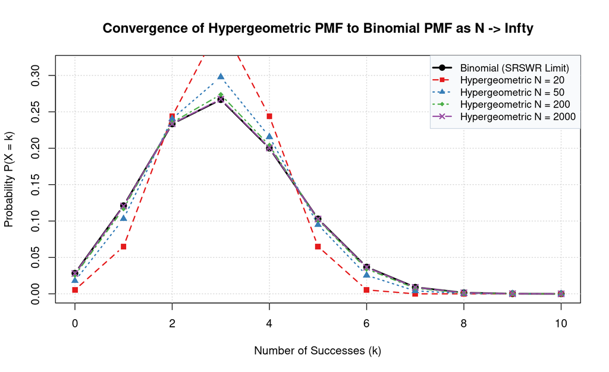

```r
# Plotting PMF convergence
plot(k_vals, binom_pmf, type = "b", pch = 19, col = "black", lwd = 2.5,
     ylim = c(0, max(binom_pmf) * 1.18),
     xlab = "Number of Successes (k)", ylab = "Probability P(X = k)",
     main = "Convergence of Hypergeometric PMF to Binomial PMF as N -> Infty")
grid(col = "lightgray", lty = "dotted")

colors <- c("#e41a1c", "#377eb8", "#4daf4a", "#984ea3")
pch_vec <- c(15, 17, 18, 4)
lty_vec <- c(2, 3, 4, 5)

for (i in seq_along(N_vec)) {
  N <- N_vec[i]
  M <- round(N * p)
  hyp_pmf <- dhyper(k_vals, m = M, n = N - M, k = n)
  lines(k_vals, hyp_pmf, type = "b", pch = pch_vec[i], col = colors[i],
        lty = lty_vec[i], lwd = 1.8, cex = 1.1)
}

legend("topright",
       legend = c("Binomial (SRSWR Limit)", paste("Hypergeometric N =", N_vec)),
       col = c("black", colors),
       lty = c(1, lty_vec),
       pch = c(19, pch_vec),
       lwd = c(2.5, rep(1.8, length(N_vec))),
       bg = "#f8fafc", box.col = "#cbd5e1", cex = 0.9)
```

# 7 Derivation of Inclusion Probabilities in SRSWOR and SRSWR

A fundamental topic in sampling theory is determining the probability that a specific unit $i$ from a finite population $U = \{1, 2, \dots, N\}$ is included in a sample $S$ of size $n$.

Let $I_i$ denote the **sample inclusion indicator** for unit $i$:

$$I_i = \begin{cases} 1 & \text{if unit } i \in S \\ 0 & \text{if unit } i \notin S \end{cases}$$

The probability $\pi_i = P(I_i = 1)$ is called the **first-order inclusion probability** of unit $i$. Below, we derive $\pi_i$ under both Simple Random Sampling Without Replacement (SRSWOR) and Simple Random Sampling With Replacement (SRSWR) using first-principles combinatorial reasoning.

## 7.1 Simple Random Sampling Without Replacement (SRSWOR)

Under SRSWOR, a sample of $n$ distinct units is chosen at random without replacement from the $N$ population units. All possible samples of size $n$ are equally likely.

### 7.1.1 Derivation 1: Direct Combinatorial Counting (Unordered Samples)

Method 1: Combination Counting

To find $P(I_i = 1)$ for any fixed unit $i \in \{1, 2, \dots, N\}$:

1. **Total Number of Possible Samples:** The number of ways to select an unordered sample of $n$ distinct units from $N$ population units is:
   $$\binom{N}{n} = \frac{N!}{n!(N-n)!}$$
2. **Favorable Samples Containing Unit $i$:** If unit $i$ must be present in the sample, its position is fixed. We are free to select the remaining $n-1$ sample units from the remaining $N-1$ population units:
   $$\binom{N-1}{n-1} = \frac{(N-1)!}{(n-1)!(N-n)!}$$
3. **Inclusion Probability:** Under equal likelihood, the ratio of favorable samples to total samples gives:
   $$P(I_i = 1) = \frac{\binom{N-1}{n-1}}{\binom{N}{n}} = \frac{\frac{(N-1)!}{(n-1)!(N-n)!}}{\frac{N!}{n!(N-n)!}} = \frac{(N-1)!}{N!} \cdot \frac{n!}{(n-1)!} = \frac{n}{N}$$

Thus, for every unit $i = 1, 2, \dots, N$, the inclusion probability in SRSWOR is simply $\pi_i = \frac{n}{N}$.

### 7.1.2 Draw-by-Draw Analysis in SRSWOR

It is instructive to distinguish the overall inclusion probability $\pi_i = P(I_i = 1)$ from the probability that unit $i$ appears on a **specific draw** $k$.

Define the specific draw indicator $X_{ik}$ for $i \in \{1, \dots, N\}$ and $k \in \{1, \dots, n\}$ as:

$$X_{ik} = \begin{cases} 1 & \text{if unit } i \text{ appears in the } k\text{-th draw of the sample} \\ 0 & \text{otherwise} \end{cases}$$

**Specific Draw Probability Theorem (SRSWOR)**  
The probability that unit $i$ is selected on the $k$-th draw is equal to $\frac{1}{N}$ for every draw $k = 1, 2, \dots, n$.

**Proof: Telescoping Conditional Product**

For unit $i$ to be selected specifically on draw $k$, it must **not** be selected on draws $1, 2, \dots, k-1$, and then **must** be selected on draw $k$.

Applying the sequential probability rule across draws:

$$\begin{aligned}
P(X_{ik} = 1) &= \underbrace{\left(\frac{N-1}{N}\right)}_{\text{Not on draw 1}} \cdot \underbrace{\left(\frac{N-2}{N-1}\right)}_{\text{Not on draw 2}} \cdots \underbrace{\left(\frac{N-k+1}{N-k+2}\right)}_{\text{Not on draw } k-1} \cdot \underbrace{\left(\frac{1}{N-k+1}\right)}_{\text{Selected on draw } k} \cdot \underbrace{\left(\frac{N-k}{N-k}\dots \frac{N-n}{N-n}\right)}_{\text{Subsequent draws}}
\end{aligned}$$

Notice the telescoping cancellation across all intermediate numerators and denominators:

$$P(X_{ik} = 1) = \frac{\cancel{N-1}}{N} \cdot \frac{\cancel{N-2}}{\cancel{N-1}} \cdot \frac{\cancel{N-3}}{\cancel{N-2}} \dots \frac{\cancel{N-k+1}}{\cancel{N-k+2}} \cdot \frac{1}{\cancel{N-k+1}} = \frac{1}{N}$$

Thus, every single draw $k \in \{1, \dots, n\}$ has an identical probability $\frac{1}{N}$ of selecting unit $i$.

### 7.1.3 Derivation 2: Alternative Inclusion Derivation via Mutually Exclusive Draw Events

We can now re-derive $P(I_i = 1)$ using the specific draw probabilities $P(X_{ik} = 1) = \frac{1}{N}$.

In SRSWOR, unit $i$ can appear **at most once** in the sample. Therefore, the events $\{X_{i1} = 1\}, \{X_{i2} = 1\}, \dots, \{X_{in} = 1\}$ are **mutually exclusive**.

Since unit $i$ is included in the sample if and only if it is selected on draw 1, OR draw 2, …, OR draw $n$:

$$\{I_i = 1\} = \bigcup_{k=1}^n \{X_{ik} = 1\}$$

By the finite additivity axiom for mutually exclusive events:

$$P(I_i = 1) = P\left(\bigcup_{k=1}^n \{X_{ik} = 1\}\right) = \sum_{k=1}^n P(X_{ik} = 1) = \sum_{k=1}^n \frac{1}{N} = n \times \frac{1}{N} = \frac{n}{N}$$

This confirms the result obtained from combination counting.

## 7.2 Simple Random Sampling With Replacement (SRSWR)

Under SRSWR, $n$ draws are conducted sequentially with replacement. On each draw, every unit in the population has an equal probability $\frac{1}{N}$ of being selected, independently of all other draws.

### 7.2.1 Derivation 1: Combinatorial Counting via Complement (Ordered Samples)

Method 1: Counting Ordered Sequences

1. **Total Number of Possible Ordered Samples:** Because drawing is done with replacement, each of the $n$ draws has $N$ possible outcomes, giving a total sample space size of:
   $$|\Omega_{\text{WR}}| = N^n$$
2. **Samples Excluding Unit $i$:** For unit $i$ **not** to appear in the sample, every single one of the $n$ draws must select one of the other $N-1$ remaining population units. The number of such ordered sequences is:
   $$(N-1)^n$$
3. **Non-Inclusion Probability:** Under equal likelihood, the probability that unit $i$ is excluded from the sample is:
   $$P(I_i = 0) = \frac{(N-1)^n}{N^n} = \left(\frac{N-1}{N}\right)^n = \left(1 - \frac{1}{N}\right)^n$$
4. **Inclusion Probability:** By the complement rule, the inclusion probability $\pi_i = P(I_i = 1)$ under SRSWR is:
   $$P(I_i = 1) = 1 - P(I_i = 0) = 1 - \left(1 - \frac{1}{N}\right)^n \quad \text{for } i = 1, 2, \dots, N$$

### 7.2.2 Draw-by-Draw Analysis and Complementary Product in SRSWR

Let $X_{ik} = 1$ if unit $i$ is selected on draw $k$, and $0$ otherwise. Because each draw is conducted independently with replacement:

$$P(X_{ik} = 1) = \frac{1}{N} \quad \text{and} \quad P(X_{ik} = 0) = 1 - \frac{1}{N} \quad \text{for all } k = 1, 2, \dots, n$$

**Derivation 2: Product Rule for Independent Complements**  
Unit $i$ is excluded from the sample if and only if it fails to be drawn on draw 1, AND on draw 2, …, AND on draw $n$:

$$\{I_i = 0\} = \bigcap_{k=1}^n \{X_{ik} = 0\}$$

Because the draws are independent in SRSWR, the joint probability factors into a product:

$$P(I_i = 0) = P\left(\bigcap_{k=1}^n \{X_{ik} = 0\}\right) = \prod_{k=1}^n P(X_{ik} = 0) = \prod_{k=1}^n \left(1 - \frac{1}{N}\right) = \left(1 - \frac{1}{N}\right)^n$$

Applying the complement rule gives:

$$P(I_i = 1) = 1 - \left(1 - \frac{1}{N}\right)^n$$

## 7.3 Comparison: SRSWOR vs. SRSWR Inclusion Probabilities

Comparing the inclusion probabilities across the two designs:

$$\pi_i^{\text{WOR}} = \frac{n}{N} \qquad \text{vs.} \qquad \pi_i^{\text{WR}} = 1 - \left(1 - \frac{1}{N}\right)^n$$

For sample size $n = 1$, both probabilities are identical: $\pi_i^{\text{WOR}} = \pi_i^{\text{WR}} = \frac{1}{N}$.

For $n \ge 2$ and $N \ge 2$, we claim that $\pi_i^{\text{WR}} < \pi_i^{\text{WOR}}$. Proving this is equivalent to showing that:

$$\left(1 - \frac{1}{N}\right)^n > 1 - \frac{n}{N}$$

**Formal Proofs of the Strict Inequality**

Method 1: Proof via Bernoulli’s Inequality (Direct & Shortest)

**Bernoulli’s Inequality:** For any real number $x > -1$ with $x \neq 0$ and any integer $n \ge 2$:

$$(1 + x)^n > 1 + nx$$

Setting $x = -\frac{1}{N}$:

1. Since population size $N \ge 2$, we have $x = -\frac{1}{N} \in [-0.5, 0)$, which satisfies $x > -1$ and $x \neq 0$.
2. Applying Bernoulli’s Inequality yields:
   $$\left(1 - \frac{1}{N}\right)^n > 1 + n\left(-\frac{1}{N}\right) = 1 - \frac{n}{N}$$
3. Multiplying both sides by $-1$ (reversing the inequality direction) and adding $1$:
   $$1 - \left(1 - \frac{1}{N}\right)^n < \frac{n}{N} \implies \pi_i^{\text{WR}} < \pi_i^{\text{WOR}} \quad \blacksquare$$

Method 2: Proof via Binomial Expansion Term-Pairing

To prove the inequality directly from the binomial expansion without ignoring alternating signs, expand $(1 - x)^n$ where $x = \frac{1}{N}$:

$$\left(1 - x\right)^n = 1 - nx + \sum_{k=2}^n (-1)^k \binom{n}{k} x^k$$

We need to show that the remainder series $R = \sum_{k=2}^n (-1)^k \binom{n}{k} x^k > 0$. Group adjacent terms into pairs $(T_k, T_{k+1})$ starting at $k=2$ for even $k$:

$$T_k + T_{k+1} = \binom{n}{k} x^k - \binom{n}{k+1} x^{k+1} = \binom{n}{k} x^k \left( 1 - \frac{n-k}{k+1} x \right)$$

Because $n \le N$ in valid sampling designs, $x = \frac{1}{N} \le \frac{1}{n}$. Thus:

$$\frac{n-k}{k+1} x \le \frac{n-k}{(k+1)n} < 1 \implies \left( 1 - \frac{n-k}{k+1} x \right) > 0$$

Since every even term $T_k$ is strictly greater in magnitude than its following odd term $T_{k+1}$, every paired sum is strictly positive. If $n$ is even, the final term $T_n = x^n > 0$ is also positive. Thus, the total sum of remaining terms is strictly positive ($R > 0$), establishing:

$$\left(1 - \frac{1}{N}\right)^n = 1 - \frac{n}{N} + R > 1 - \frac{n}{N} \implies \pi_i^{\text{WR}} < \pi_i^{\text{WOR}} \quad \blacksquare$$

Method 3: Proof via Mathematical Induction on $n$

- **Base Case ($n = 2$):**
  $$\left(1 - \frac{1}{N}\right)^2 = 1 - \frac{2}{N} + \frac{1}{N^2} > 1 - \frac{2}{N} \quad \text{since } \frac{1}{N^2} > 0$$
  The base case holds strictly.
- **Inductive Hypothesis:** Assume $\left(1 - \frac{1}{N}\right)^k > 1 - \frac{k}{N}$ holds for some integer $k \ge 2$.
- **Inductive Step ($k \to k+1$):** Multiply both sides by $\left(1 - \frac{1}{N}\right) > 0$:
  $$\begin{aligned}
  \left(1 - \frac{1}{N}\right)^{k+1} &> \left(1 - \frac{k}{N}\right)\left(1 - \frac{1}{N}\right) \\
  &= 1 - \frac{k}{N} - \frac{1}{N} + \frac{k}{N^2} \\
  &= 1 - \frac{k+1}{N} + \frac{k}{N^2}
  \end{aligned}$$
  Since $k \ge 2$ and $N \ge 2$, the term $\frac{k}{N^2} > 0$. Therefore:
  $$\left(1 - \frac{1}{N}\right)^{k+1} > 1 - \frac{k+1}{N}$$
  By induction, the inequality holds for all integers $n \ge 2$. $\blacksquare$

**Optional Review: Elementary Proofs of Bernoulli’s Inequality**

Theorem: Bernoulli’s Inequality

For any integer $n \ge 1$ and any real number $x \ge -1$:

$$(1 + x)^n \ge 1 + nx$$

Furthermore, if $n \ge 2$ and $x \neq 0$, the inequality is strict: $(1 + x)^n > 1 + nx$.

Proof 1: By Mathematical Induction (Most General)

- **Base Case ($n = 1$):**
  $$(1 + x)^1 = 1 + 1 \cdot x = 1 + x$$
  The inequality holds (as an equality). For $n = 2$ with $x \neq 0$:
  $$(1 + x)^2 = 1 + 2x + x^2 > 1 + 2x \quad \text{since } x^2 > 0$$
- **Inductive Hypothesis:** Assume $(1 + x)^k \ge 1 + kx$ holds for some integer $k \ge 1$.
- **Inductive Step ($k \to k+1$):** Since $x \ge -1$, we know that $(1 + x) \ge 0$. Multiplying both sides of the hypothesis by $(1 + x)$ preserves the inequality:
  $$\begin{aligned}
  (1 + x)^{k+1} &\ge (1 + kx)(1 + x) \\
  &= 1 + x + kx + kx^2 \\
  &= 1 + (k + 1)x + \underbrace{kx^2}_{\ge 0} \\
  &\ge 1 + (k + 1)x
  \end{aligned}$$

  Since $k \ge 1$ and $x^2 \ge 0$, dropping $kx^2$ yields $(1 + x)^{k+1} \ge 1 + (k+1)x$. If $x \neq 0$, $kx^2 > 0$, making the inequality strict. By induction, the statement holds for all $n \ge 1$. $\blacksquare$

Proof 2: By Calculus / Minimization (For $x > -1$)

Define the differentiable function $f(x) = (1 + x)^n - (1 + nx)$ on the domain $x \in (-1, \infty)$ for fixed $n \ge 2$.

1. **Find Critical Points:** Take the first derivative with respect to $x$:
   $$f'(x) = n(1 + x)^{n-1} - n = n \left[ (1 + x)^{n-1} - 1 \right]$$
   Setting $f'(x) = 0$ yields $(1 + x)^{n-1} = 1 \implies x = 0$.
2. **Determine Sign of Derivative:**
   - For $-1 < x < 0$: $(1 + x) < 1 \implies (1 + x)^{n-1} < 1 \implies f'(x) < 0$ (function is strictly decreasing).
   - For $x > 0$: $(1 + x) > 1 \implies (1 + x)^{n-1} > 1 \implies f'(x) > 0$ (function is strictly increasing).
3. **Conclusion:** $x = 0$ is the unique global minimum of $f(x)$ on $(-1, \infty)$. Since $f(0) = (1+0)^n - (1 + 0) = 0$, we have $f(x) > f(0) = 0$ for all $x \neq 0$. Thus:
   $$(1 + x)^n - (1 + nx) > 0 \implies (1 + x)^n > 1 + nx \quad \blacksquare$$

Proof 3: By Binomial Expansion (Direct for $x \ge 0$)

For $x \ge 0$ and integer $n \ge 2$, expand $(1 + x)^n$ directly using the Binomial Theorem:

$$(1 + x)^n = \sum_{k=0}^n \binom{n}{k} x^k = 1 + nx + \binom{n}{2}x^2 + \binom{n}{3}x^3 + \dots + x^n$$

Since $x \ge 0$, every term $\binom{n}{k} x^k \ge 0$ for $k \ge 2$. Truncating the expansion after the first two terms immediately gives:

$$(1 + x)^n = 1 + nx + \underbrace{\sum_{k=2}^n \binom{n}{k} x^k}_{\ge 0} \ge 1 + nx$$

If $x > 0$, the term $\binom{n}{2}x^2 > 0$, making the inequality strictly greater. $\blacksquare$

**Intuitive Summary:**  
In SRSWR, duplicate draws of the same unit are allowed, which “wastes” sample slots on already-selected items. Consequently, the probability of including any given distinct unit $i$ in SRSWR is **strictly less** than in SRSWOR ($\pi_i^{\text{WR}} < \pi_i^{\text{WOR}}$ for $n > 1$). However, as $N \to \infty$, applying $(1 - 1/N)^n \approx 1 - n/N$ shows that both inclusion probabilities converge to $\frac{n}{N}$.

# 8 Summary and Outlook

In this lecture, we covered:

1. Feller’s classical combinatorial framework for equally likely sample spaces.
2. The sock/shoe matching problem and non-replacement pair probabilities.
3. General multivariate hypergeometric probabilities for multi-category selections (poker and bridge hands).
4. Derivation of first-order inclusion probabilities $\pi_i$ in SRSWOR ($\frac{n}{N}$) and SRSWR ($1 - (1 - \frac{1}{N})^n$) using direct combinatorics and draw-by-draw probability rules.
5. The exact relationship between SRSWOR (Hypergeometric) and SRSWR (Binomial).
6. Mathematical proof and numerical/graphical validation of the limit $\text{Hypergeometric}(N, M, n) \to \text{Binomial}(n, p)$ as $N \to \infty$.

In **Lecture 3**, we will move into the concepts of **Expectations and Unbiasedness**, analyzing unbiased estimation of population quantities from the sample.